# Multivariate statistics

## Principal component analysis (PCA)

PCA allows you to see the overall “shape” of the data, identifying which samples are similar to one another and which are very different. This can enable us to identify groups of samples that are similar and work out which variables make one group different from another.

PCA is a type of linear transformation on a given data set that has values for a certain number of variables (coordinates) for a certain amount of spaces. This linear transformation fits this dataset to a new coordinate system in such a way that the most significant variance is found on the first coordinate, and each subsequent coordinate is orthogonal to the last and has a lesser variance. In this way, you transform a set of x correlated variables over y samples to a set of p uncorrelated principal components over the same samples.

Principal Components are the underlying structure in the data. They are the directions where there is the most variance, the directions where the data is most spread out.

You can perform a Principal Component Analysis (PCA) using the built-in R functions prcomp() and princomp(). The function princomp() uses the **spectral decomposition** approach. The functions prcomp() and PCA()[FactoMineR] use the **singular value decomposition (SVD)**. For differences between the two functions, see this [blog](http://www.sthda.com/english/articles/31-principal-component-methods-in-r-practical-guide/118-principal-component-analysis-in-r-prcomp-vs-princomp/).

According to the R help, SVD has slightly better numerical accuracy. Therefore, the function prcomp() is preferred compared to princomp(). To perform PCA on gene expression data, use the **prcomp()** function because of small sample size (n << p).

PCA is applied on a data set with numeric variables. If different features have very different scales, standardize the data (Center and scale) first.

You can plot PCA/clustering results using ggplot2 and ggfortify by referring to [this Blog](http://rpubs.com/sinhrks/plot_pca), You can make animated 3D PCA plots by refering to [this blog](https://2-bitbio.com/2017/04/animated-3d-pca-plots-in-r.html).

```r
# for visualization of PCA results
if (!require("factoextra")) install.packages("factoextra")
library(factoextra)

fit <- prcomp(mtcars, retx = TRUE, center = TRUE, scale. = TRUE)
summary(fit) # print variance accounted for
```

```
Importance of components:
                          PC1    PC2     PC3     PC4
Standard deviation     2.5707 1.6280 0.79196 0.51923
Proportion of Variance 0.6008 0.2409 0.05702 0.02451
Cumulative Proportion  0.6008 0.8417 0.89873 0.92324
                           PC5     PC6    PC7     PC8
Standard deviation     0.47271 0.46000 0.3678 0.35057
Proportion of Variance 0.02031 0.01924 0.0123 0.01117
Cumulative Proportion  0.94356 0.96279 0.9751 0.98626
                          PC9    PC10   PC11
Standard deviation     0.2776 0.22811 0.1485
Proportion of Variance 0.0070 0.00473 0.0020
Cumulative Proportion  0.9933 0.99800 1.0000
```

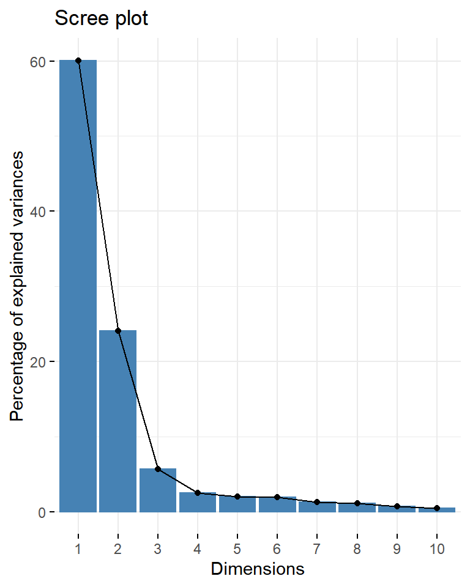

```r
# visualization of Eigenvalues (variance)
fviz_eig(fit)
```

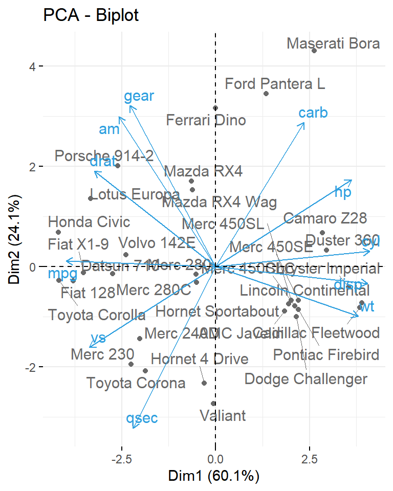

```r
# biplot
fviz_pca_biplot(fit, repel = TRUE,
        col.var = "#2E9FDF", # Variables color
        col.ind = "#696969") # Individuals color
```

```r
fit$rotation # pc loadings
```

```
            PC1         PC2         PC3          PC4
mpg  -0.3625305  0.01612440 -0.22574419 -0.022540255
cyl   0.3739160  0.04374371 -0.17531118 -0.002591838
disp  0.3681852 -0.04932413 -0.06148414  0.256607885
hp    0.3300569  0.24878402  0.14001476 -0.067676157
drat -0.2941514  0.27469408  0.16118879  0.854828743
wt    0.3461033 -0.14303825  0.34181851  0.245899314
qsec -0.2004563 -0.46337482  0.40316904  0.068076532
vs   -0.3065113 -0.23164699  0.42881517 -0.214848616
am   -0.2349429  0.42941765 -0.20576657 -0.030462908
gear -0.2069162  0.46234863  0.28977993 -0.264690521
carb  0.2140177  0.41357106  0.52854459 -0.126789179
             PC5         PC6          PC7          PC8
mpg   0.10284468 -0.10879743  0.367723810 -0.754091423
cyl   0.05848381  0.16855369  0.057277736 -0.230824925
disp  0.39399530 -0.33616451  0.214303077  0.001142134
hp    0.54004744  0.07143563 -0.001495989 -0.222358441
drat  0.07732727  0.24449705  0.021119857  0.032193501
wt   -0.07502912 -0.46493964 -0.020668302 -0.008571929
qsec -0.16466591 -0.33048032  0.050010522 -0.231840021
vs    0.59953955  0.19401702 -0.265780836  0.025935128
am    0.08978128 -0.57081745 -0.587305101 -0.059746952
gear  0.04832960 -0.24356284  0.605097617  0.336150240
carb -0.36131875  0.18352168 -0.174603192 -0.395629107
              PC9        PC10         PC11
mpg   0.235701617  0.13928524 -0.124895628
cyl   0.054035270 -0.84641949 -0.140695441
disp  0.198427848  0.04937979  0.660606481
hp   -0.575830072  0.24782351 -0.256492062
drat -0.046901228 -0.10149369 -0.039530246
wt    0.359498251  0.09439426 -0.567448697
qsec -0.528377185 -0.27067295  0.181361780
vs    0.358582624 -0.15903909  0.008414634
am   -0.047403982 -0.17778541  0.029823537
gear -0.001735039 -0.21382515 -0.053507085
carb  0.170640677  0.07225950  0.319594676
```

```r
fit$x # the principal components
```

```
                              PC1        PC2        PC3
Mazda RX4           -0.6468627420  1.7081142 -0.5917309
Mazda RX4 Wag       -0.6194831460  1.5256219 -0.3763013
Datsun 710          -2.7356242748 -0.1441501 -0.2374391
Hornet 4 Drive      -0.3068606268 -2.3258038 -0.1336213
Hornet Sportabout    1.9433926844 -0.7425211 -1.1165366
Valiant             -0.0552534228 -2.7421229  0.1612456
Duster 360           2.9553851233  0.3296133 -0.3570461
Merc 240D           -2.0229593244 -1.4421056  0.9290295
Merc 230            -2.2513839535 -1.9522879  1.7689364
Merc 280            -0.5180912217 -0.1594610  1.4692603
Merc 280C           -0.5011860079 -0.3187934  1.6570701
Merc 450SE           2.2124096339 -0.6727099 -0.3694707
Merc 450SL           2.0155715693 -0.6724606 -0.4768341
Merc 450SLC          2.1147047372 -0.7891129 -0.2904620
Cadillac Fleetwood   3.8383725118 -0.8149087  0.6370972
Lincoln Continental  3.8918495626 -0.7218314  0.7092612
Chrysler Imperial    3.5363862158 -0.4145024  0.5402468
Fiat 128            -3.7955510831 -0.2920783 -0.4161681
Honda Civic         -4.1870356784  0.6775721 -0.2035831
Toyota Corolla      -4.1675359344 -0.2748890 -0.4589124
Toyota Corona       -1.8741790870 -2.0864529  0.1543265
Dodge Challenger     2.1504414942 -0.9982442 -1.1503639
AMC Javelin          1.8340369797 -0.8921886 -0.9472872
Camaro Z28           2.8434957523  0.6701037 -0.1605593
Pontiac Firebird     2.2105479148 -0.8600504 -1.0279577
Fiat X1-9           -3.5176818134 -0.1192950 -0.4464716
Porsche 914-2       -2.6095003965  2.0141425 -0.8172519
Lotus Europa        -3.3323844512  1.3568877 -0.4467167
Ford Pantera L       1.3513346957  3.4448780 -0.1343943
Ferrari Dino        -0.0009743305  3.1683750  0.3957610
Maserati Bora        2.6270897605  4.3107016  1.3315940
Volvo 142E          -2.3824711412  0.2299603  0.4052798
                             PC4          PC5
Mazda RX4            0.113702214 -0.945523363
Mazda RX4 Wag        0.199121210 -1.016680740
Datsun 710          -0.245215450  0.398762288
Hornet 4 Drive      -0.503800355  0.549208936
Hornet Sportabout    0.074461963  0.207515698
Valiant             -0.975167425  0.211665375
```

[output cut: 77 more lines]

```
Fiat 128             0.10550311 -0.02717077 -0.208865888
Honda Civic          0.23711675 -0.15433928  0.246835364
Toyota Corolla      -0.11313627 -0.12606845 -0.031747839
Toyota Corona       -0.44646972  0.51147635  0.063679725
Dodge Challenger     0.10435633 -0.13641143  0.049594456
AMC Javelin         -0.12237636 -0.29628634  0.045293027
Camaro Z28          -0.05282991  0.32624525 -0.099386307
Pontiac Firebird     0.20849043  0.01547674  0.122593248
Fiat X1-9           -0.02228967 -0.08414018 -0.005746448
Porsche 914-2       -0.12999660  0.34968156 -0.111596656
Lotus Europa         0.29680350  0.23980308  0.030015592
Ford Pantera L      -0.23280792 -0.50262890 -0.042242570
Ferrari Dino         0.09813571  0.14491815  0.043006835
Maserati Bora       -0.34081133  0.04706368  0.062135486
Volvo 142E          -0.04473670  0.11767108 -0.145329008
```

```r
# Access PCA results
# Eigenvalues
eig.val <- get_eigenvalue(fit)
eig.val
```

|  | eigenvalue | variance.percent | cumulative.variance.percent |
| --- | --- | --- | --- |
| Dim.1 | 6.60840025 | 60.0763659 | 60.07637 |
| Dim.2 | 2.65046789 | 24.0951627 | 84.17153 |
| Dim.3 | 0.62719727 | 5.7017934 | 89.87332 |
| Dim.4 | 0.26959744 | 2.4508858 | 92.32421 |
| Dim.5 | 0.22345110 | 2.0313737 | 94.35558 |
| Dim.6 | 0.21159612 | 1.9236011 | 96.27918 |
| Dim.7 | 0.13526199 | 1.2296544 | 97.50884 |
| Dim.8 | 0.12290143 | 1.1172858 | 98.62612 |
| Dim.9 | 0.07704665 | 0.7004241 | 99.32655 |
| Dim.10 | 0.05203544 | 0.4730495 | 99.79960 |

[output cut: 1 more lines]

```r
# Results for Variables
res.var <- get_pca_var(fit)
res.var$coord     # Coordinates
```

```
          Dim.1       Dim.2       Dim.3        Dim.4
mpg  -0.9319502  0.02625094 -0.17877989 -0.011703525
cyl   0.9612188  0.07121589 -0.13883907 -0.001345754
disp  0.9464866 -0.08030095 -0.04869285  0.133237930
hp    0.8484710  0.40502680  0.11088579 -0.035139337
drat -0.7561693  0.44720905  0.12765473  0.443850788
wt    0.8897212 -0.23286996  0.27070586  0.127677743
qsec -0.5153093 -0.75438614  0.31929289  0.035347223
vs   -0.7879428 -0.37712727  0.33960355 -0.111555360
am   -0.6039632  0.69910300 -0.16295845 -0.015817187
gear -0.5319156  0.75271549  0.22949350 -0.137434658
carb  0.5501711  0.67330434  0.41858505 -0.065832458
           Dim.5       Dim.6         Dim.7         Dim.8
mpg   0.04861531 -0.05004636  0.1352413926 -0.2643640975
cyl   0.02764565  0.07753399  0.0210655949 -0.0809209881
disp  0.18624400 -0.15463426  0.0788163447  0.0004004013
hp    0.25528375  0.03286009 -0.0005501946 -0.0779528673
drat  0.03655308  0.11246761  0.0077674570  0.0112861725
wt   -0.03546673 -0.21387027 -0.0076013843 -0.0030050869
qsec -0.07783859 -0.15201955  0.0183928603 -0.0812768533
vs    0.28340603  0.08924701 -0.0977488250  0.0090921558
am    0.04244016 -0.26257362 -0.2159989575 -0.0209456686
gear  0.02284570 -0.11203788  0.2225426856  0.1178452002
carb -0.17079759  0.08441920 -0.0642155284 -0.1386968855
             Dim.9      Dim.10       Dim.11
mpg   0.0654243559  0.03177274 -0.018543702
cyl   0.0149987209 -0.19307910 -0.020889557
disp  0.0550781718  0.01126416  0.098082614
hp   -0.1598347609  0.05653171 -0.038082296
drat -0.0130185049 -0.02315201 -0.005869197
wt    0.0997869332  0.02153254 -0.084251143
qsec -0.1466631306 -0.06174396  0.026927434
vs    0.0995327801 -0.03627885  0.001249351
am   -0.0131580558 -0.04055512  0.004428008
gear -0.0004815997 -0.04877625 -0.007944389
carb  0.0473652092  0.01648332  0.047451368
```

```r
res.var$contrib    # Contributions to the PCs
```

```
         Dim.1       Dim.2      Dim.3        Dim.4
mpg  13.142837  0.02599962  5.0960440 5.080631e-02
cyl  13.981320  0.19135124  3.0734010 6.717622e-04
disp 13.556034  0.24328694  0.3780299 6.584761e+00
hp   10.893757  6.18934888  1.9604134 4.580062e-01
drat  8.652504  7.54568403  2.5981826 7.307322e+01
wt   11.978751  2.04599412 11.6839894 6.046647e+00
qsec  4.018275 21.47162226 16.2545274 4.634414e-01
vs    9.394919  5.36603293 18.3882452 4.615993e+00
am    5.519816 18.43995209  4.2339880 9.279888e-02
gear  4.281433 21.37662593  8.3972408 7.006107e+00
carb  4.580356 17.10410194 27.9359384 1.607550e+00
          Dim.5      Dim.6        Dim.7        Dim.8
mpg   1.0577029  1.1836881 1.352208e+01 56.865387485
cyl   0.3420355  2.8410348 3.280739e-01  5.328014619
disp 15.5232297 11.3006579 4.592581e+00  0.000130447
hp   29.1651238  0.5103049 2.237983e-04  4.944327640
drat  0.5979507  5.9778807 4.460484e-02  0.103642152
wt    0.5629370 21.6168867 4.271787e-02  0.007347797
qsec  2.7114861 10.9217243 2.501052e-01  5.374979545
vs   35.9447677  3.7642604 7.063945e+00  0.067263086
am    0.8060678 32.5832557 3.449273e+01  0.356969826
gear  0.2335750  5.9322858 3.661431e+01 11.299698364
carb 13.0551238  3.3680207 3.048627e+00 15.652239039
            Dim.9     Dim.10       Dim.11
mpg  5.555525e+00  1.9400379  1.559891780
cyl  2.919810e-01 71.6425959  1.979520716
disp 3.937361e+00  0.2438363 43.640092321
hp   3.315803e+01  6.1416490  6.578817788
drat 2.199725e-01  1.0300969  0.156264034
wt   1.292390e+01  0.8910277 32.199802381
qsec 2.791825e+01  7.3263846  3.289209524
vs   1.285815e+01  2.5293432  0.007080607
am   2.247138e-01  3.1607652  0.088944337
gear 3.010361e-04  4.5721196  0.286300810
carb 2.911824e+00  0.5221436 10.214075702
```

```r
res.var$cos2      # Quality of representation
```

```
         Dim.1        Dim.2       Dim.3        Dim.4
mpg  0.8685312 0.0006891117 0.031962249 1.369725e-04
cyl  0.9239416 0.0050717032 0.019276287 1.811054e-06
disp 0.8958370 0.0064482423 0.002370993 1.775235e-02
hp   0.7199031 0.1640467049 0.012295659 1.234773e-03
drat 0.5717921 0.1999959326 0.016295731 1.970035e-01
wt   0.7916038 0.0542284172 0.073281663 1.630161e-02
qsec 0.2655437 0.5690984542 0.101947952 1.249426e-03
vs   0.6208539 0.1422249798 0.115330572 1.244460e-02
am   0.3647715 0.4887450097 0.026555457 2.501834e-04
gear 0.2829342 0.5665806069 0.052667265 1.888829e-02
carb 0.3026882 0.4533387304 0.175213444 4.333912e-03
            Dim.5       Dim.6        Dim.7        Dim.8
mpg  0.0023634487 0.002504638 1.829023e-02 6.988838e-02
cyl  0.0007642822 0.006011519 4.437593e-04 6.548206e-03
disp 0.0346868281 0.023911754 6.212016e-03 1.603212e-07
hp   0.0651697911 0.001079785 3.027140e-07 6.076650e-03
drat 0.0013361275 0.012648964 6.033339e-05 1.273777e-04
wt   0.0012578888 0.045740494 5.778104e-05 9.030547e-06
qsec 0.0060588455 0.023109945 3.382973e-04 6.605927e-03
vs   0.0803189801 0.007965029 9.554833e-03 8.266730e-05
am   0.0018011675 0.068944905 4.665555e-02 4.387210e-04
gear 0.0005219259 0.012552487 4.952525e-02 1.388749e-02
carb 0.0291718181 0.007126601 4.123634e-03 1.923683e-02
            Dim.9       Dim.10       Dim.11
mpg  4.280346e-03 0.0010095073 3.438689e-04
cyl  2.249616e-04 0.0372795406 4.363736e-04
disp 3.033605e-03 0.0001268813 9.620199e-03
hp   2.554715e-02 0.0031958341 1.450261e-03
drat 1.694815e-04 0.0005360155 3.444748e-05
wt   9.957432e-03 0.0004636502 7.098255e-03
qsec 2.151007e-02 0.0038123165 7.250867e-04
vs   9.906774e-03 0.0013161549 1.560878e-06
am   1.731344e-04 0.0016447181 1.960725e-05
gear 2.319383e-07 0.0023791226 6.311331e-05
carb 2.243463e-03 0.0002716997 2.251632e-03
```

```r
# Results for individuals
res.ind <- get_pca_ind(fit)
res.ind$coord     # Coordinates
```

```
                            Dim.1      Dim.2      Dim.3
Mazda RX4           -0.6468627420  1.7081142 -0.5917309
Mazda RX4 Wag       -0.6194831460  1.5256219 -0.3763013
Datsun 710          -2.7356242748 -0.1441501 -0.2374391
Hornet 4 Drive      -0.3068606268 -2.3258038 -0.1336213
Hornet Sportabout    1.9433926844 -0.7425211 -1.1165366
Valiant             -0.0552534228 -2.7421229  0.1612456
Duster 360           2.9553851233  0.3296133 -0.3570461
Merc 240D           -2.0229593244 -1.4421056  0.9290295
Merc 230            -2.2513839535 -1.9522879  1.7689364
Merc 280            -0.5180912217 -0.1594610  1.4692603
Merc 280C           -0.5011860079 -0.3187934  1.6570701
Merc 450SE           2.2124096339 -0.6727099 -0.3694707
Merc 450SL           2.0155715693 -0.6724606 -0.4768341
Merc 450SLC          2.1147047372 -0.7891129 -0.2904620
Cadillac Fleetwood   3.8383725118 -0.8149087  0.6370972
Lincoln Continental  3.8918495626 -0.7218314  0.7092612
Chrysler Imperial    3.5363862158 -0.4145024  0.5402468
Fiat 128            -3.7955510831 -0.2920783 -0.4161681
Honda Civic         -4.1870356784  0.6775721 -0.2035831
Toyota Corolla      -4.1675359344 -0.2748890 -0.4589124
Toyota Corona       -1.8741790870 -2.0864529  0.1543265
Dodge Challenger     2.1504414942 -0.9982442 -1.1503639
AMC Javelin          1.8340369797 -0.8921886 -0.9472872
Camaro Z28           2.8434957523  0.6701037 -0.1605593
Pontiac Firebird     2.2105479148 -0.8600504 -1.0279577
Fiat X1-9           -3.5176818134 -0.1192950 -0.4464716
Porsche 914-2       -2.6095003965  2.0141425 -0.8172519
Lotus Europa        -3.3323844512  1.3568877 -0.4467167
Ford Pantera L       1.3513346957  3.4448780 -0.1343943
Ferrari Dino        -0.0009743305  3.1683750  0.3957610
Maserati Bora        2.6270897605  4.3107016  1.3315940
Volvo 142E          -2.3824711412  0.2299603  0.4052798
                           Dim.4        Dim.5
Mazda RX4            0.113702214 -0.945523363
Mazda RX4 Wag        0.199121210 -1.016680740
Datsun 710          -0.245215450  0.398762288
Hornet 4 Drive      -0.503800355  0.549208936
Hornet Sportabout    0.074461963  0.207515698
Valiant             -0.975167425  0.211665375
```

[output cut: 77 more lines]

```
Fiat 128             0.10550311 -0.02717077 -0.208865888
Honda Civic          0.23711675 -0.15433928  0.246835364
Toyota Corolla      -0.11313627 -0.12606845 -0.031747839
Toyota Corona       -0.44646972  0.51147635  0.063679725
Dodge Challenger     0.10435633 -0.13641143  0.049594456
AMC Javelin         -0.12237636 -0.29628634  0.045293027
Camaro Z28          -0.05282991  0.32624525 -0.099386307
Pontiac Firebird     0.20849043  0.01547674  0.122593248
Fiat X1-9           -0.02228967 -0.08414018 -0.005746448
Porsche 914-2       -0.12999660  0.34968156 -0.111596656
Lotus Europa         0.29680350  0.23980308  0.030015592
Ford Pantera L      -0.23280792 -0.50262890 -0.042242570
Ferrari Dino         0.09813571  0.14491815  0.043006835
Maserati Bora       -0.34081133  0.04706368  0.062135486
Volvo 142E          -0.04473670  0.11767108 -0.145329008
```

```r
res.ind$contrib    # Contributions to the PCs
```

```
                           Dim.1       Dim.2       Dim.3
Mazda RX4           1.978691e-01  3.44002231  1.74459402
Mazda RX4 Wag       1.814733e-01  2.74423516  0.70553282
Datsun 710          3.538886e+00  0.02449950  0.28089900
Hornet 4 Drive      4.452829e-02  6.37784013  0.08896045
Hornet Sportabout   1.785973e+00  0.65004747  6.21143277
Valiant             1.443684e-03  8.86546032  0.12954525
Duster 360          4.130302e+00  0.12809638  0.63517669
Merc 240D           1.935209e+00  2.45200657  4.30036016
Merc 230            2.396916e+00  4.49381509 15.59086761
Merc 280            1.269305e-01  0.02998035 10.75581566
Merc 280C           1.187823e-01  0.11982467 13.68130747
Merc 450SE          2.314647e+00  0.53355987  0.68015199
Merc 450SL          1.921101e+00  0.53316447  1.13287125
Merc 450SLC         2.114721e+00  0.73418540  0.42036299
Cadillac Fleetwood  6.967034e+00  0.78297048  2.02235433
Lincoln Continental 7.162519e+00  0.61432622  2.50644539
Chrysler Imperial   5.913888e+00  0.20257302  1.45422039
Fiat 128            6.812451e+00  0.10058337  0.86294555
Honda Civic         8.290238e+00  0.54130067  0.20650433
Toyota Corolla      8.213200e+00  0.08909269  1.04931402
Toyota Corona       1.661024e+00  5.13268561  0.11866622
Dodge Challenger    2.186799e+00  1.17490050  6.59350573
AMC Javelin         1.590633e+00  0.93851415  4.47104695
Camaro Z28          3.823480e+00  0.52943362  0.12844480
Pontiac Firebird    2.310753e+00  0.87211815  5.26497528
Fiat X1-9           5.851494e+00  0.01677922  0.99319268
Porsche 914-2       3.220093e+00  4.78308260  3.32780384
Lotus Europa        5.251264e+00  2.17077729  0.99428365
Ford Pantera L      8.635342e-01 13.99185116  0.08999281
Ferrari Dino        4.489172e-07 11.83588186  0.78039033
Maserati Bora       3.263649e+00 21.90904218  8.83465411
Volvo 142E          2.684164e+00  0.06234954  0.81838148
                           Dim.4        Dim.5        Dim.6
Mazda RX4           1.498553e-01 1.250294e+01 4.261817e-03
Mazda RX4 Wag       4.595887e-01 1.445562e+01 8.629471e-01
Datsun 710          6.969954e-01 2.223800e+00 1.796450e+00
Hornet 4 Drive      2.942058e+00 4.218351e+00 5.499483e-03
Hornet Sportabout   6.426925e-02 6.022398e-01 3.287288e-01
Valiant             1.102282e+01 6.265665e-01 8.780868e-01
```

[output cut: 77 more lines]

```
Fiat 128             0.04433582  6.184244542
Honda Civic          1.43055233  8.637068874
Toyota Corolla       0.95447291  0.142882803
Toyota Corona       15.71093014  0.574849264
Dodge Challenger     1.11751223  0.348672647
AMC Javelin          5.27198348  0.290813330
Camaro Z28           6.39203553  1.400247255
Pontiac Firebird     0.01438500  2.130515640
Fiat X1-9            0.42516510  0.004681129
Porsche 914-2        7.34338423  1.765444164
Lotus Europa         3.45350660  0.127716043
Ford Pantera L      15.17210006  0.252960248
Ferrari Dino         1.26123605  0.262196312
Maserati Bora        0.13302171  0.547307013
Volvo 142E           0.83155364  2.994030613
```

```r
res.ind$cos2      # Quality of representation
```

```
                           Dim.1       Dim.2       Dim.3
Mazda RX4           8.656680e-02 0.603616196 0.072439529
Mazda RX4 Wag       9.149123e-02 0.554899491 0.033759176
Datsun 710          8.658556e-01 0.002404154 0.006522842
Hornet 4 Drive      1.529814e-02 0.878825380 0.002900732
Hornet Sportabout   6.462799e-01 0.094344610 0.213326802
Valiant             3.469941e-04 0.854628846 0.002955149
Duster 360          8.877547e-01 0.011042673 0.012957270
Merc 240D           5.234398e-01 0.266003023 0.110395504
Merc 230            3.754869e-01 0.282347123 0.231803541
Merc 280            7.622461e-02 0.007220910 0.613027891
Merc 280C           6.397481e-02 0.025883912 0.699347298
Merc 450SE          8.347309e-01 0.077174016 0.023279601
Merc 450SL          7.850810e-01 0.087387984 0.043939255
Merc 450SLC         7.897261e-01 0.109965204 0.014898949
Cadillac Fleetwood  8.754509e-01 0.039459852 0.024118424
Lincoln Continental 8.812753e-01 0.030315945 0.029269272
Chrysler Imperial   8.782750e-01 0.012066054 0.020497245
Fiat 128            9.365228e-01 0.005545841 0.011259166
Honda Civic         8.750766e-01 0.022916264 0.002068788
Toyota Corolla      9.337140e-01 0.004062279 0.011321781
Toyota Corona       3.901102e-01 0.483484188 0.002645126
Dodge Challenger    6.174302e-01 0.133047341 0.176686396
AMC Javelin         6.206791e-01 0.146880554 0.165582457
Camaro Z28          7.747079e-01 0.043024602 0.002470037
Pontiac Firebird    6.815003e-01 0.103160641 0.147372569
Fiat X1-9           9.670520e-01 0.001112195 0.015578454
Porsche 914-2       5.022786e-01 0.299233570 0.049265372
Lotus Europa        7.227332e-01 0.119827260 0.012987701
Ford Pantera L      1.130404e-01 0.734607907 0.001118072
Ferrari Dino        8.024003e-08 0.848499642 0.013238675
Maserati Bora       2.404418e-01 0.647375342 0.061773744
Volvo 142E          8.079067e-01 0.007526823 0.023378456
                           Dim.4        Dim.5        Dim.6
Mazda RX4           2.674638e-03 1.849574e-01 5.970072e-05
Mazda RX4 Wag       9.452692e-03 2.464278e-01 1.393036e-02
Datsun 710          6.957100e-03 1.839758e-02 1.407361e-02
Hornet 4 Drive      4.123570e-02 4.900401e-02 6.049730e-05
Hornet Sportabout   9.487864e-04 7.368879e-03 3.808860e-03
Valiant             1.080842e-01 5.092176e-03 6.757699e-03
```

[output cut: 77 more lines]

```
Fiat 128            4.799242e-05 2.835984e-03
Honda Civic         1.189010e-03 3.041218e-03
Toyota Corolla      8.544132e-04 5.418555e-05
Toyota Corona       2.905469e-02 4.503679e-04
Dodge Challenger    2.484472e-03 3.283967e-04
AMC Javelin         1.619848e-02 3.785416e-04
Camaro Z28          1.019815e-02 9.464244e-04
Pontiac Firebird    3.340606e-05 2.096039e-03
Fiat X1-9           5.532782e-04 2.580689e-06
Porsche 914-2       9.019353e-03 9.186123e-04
Lotus Europa        3.742634e-03 5.863564e-05
Ford Pantera L      1.563878e-02 1.104609e-04
Ferrari Dino        1.775105e-03 1.563340e-04
Maserati Bora       7.716706e-05 1.345054e-04
Volvo 142E          1.970813e-03 3.006149e-03
```

Determining the Number of Factors to Extract A crucial decision in exploratory factor analysis is how many factors to extract. The nFactors package offer a suite of functions to aid in this decision. Details on this methodology can be found in a PowerPoint presentation by Raiche, Riopel, and Blais. Of course, any factor solution must be interpretable to be useful.

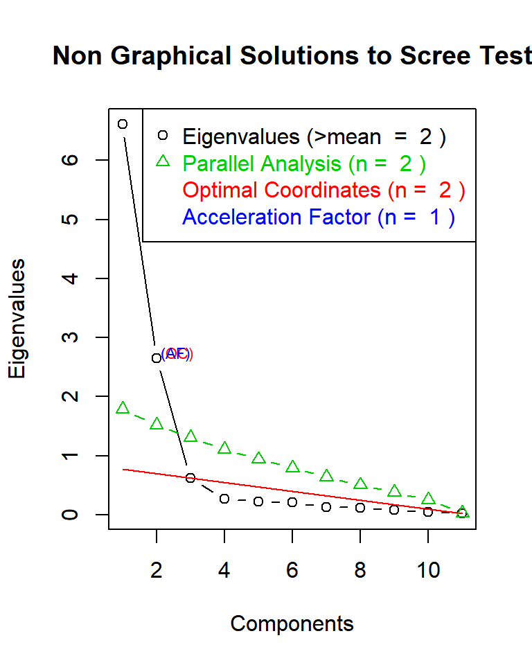

```r
# Determine Number of Factors to Extract
if (!(require("nFactors"))) install.packages("nFactors")
library(nFactors)
ev <- eigen(cor(mtcars)) # get eigenvalues
ap <- parallel(subject = nrow(mtcars),var = ncol(mtcars),
 rep = 100,cent = .05)
nS <- nScree(x = ev$values, aparallel = ap$eigen$qevpea)
plotnScree(nS)
```

Going Further The FactoMineR package offers a large number of additional functions for exploratory factor analysis. This includes the use of both quantitative and qualitative variables, as well as the inclusion of supplementary variables and observations. Here is an example of the types of graphs that you can create with this package.

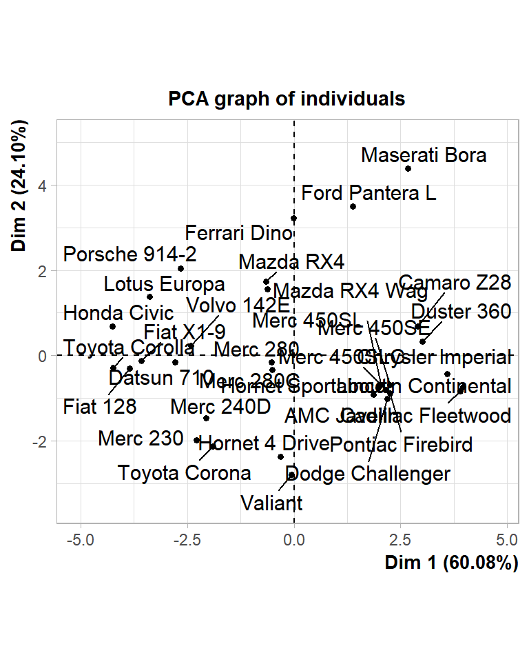

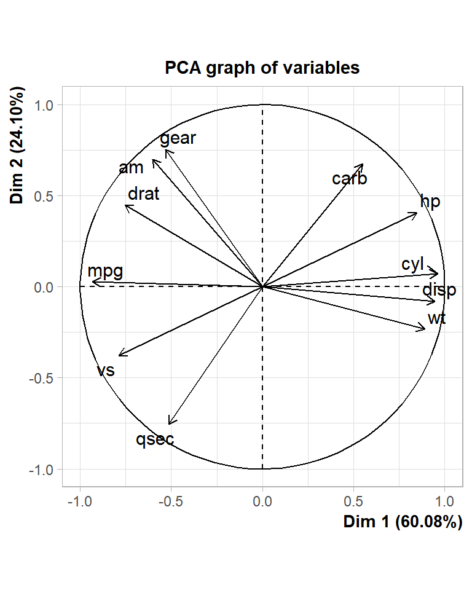

```r
# PCA Variable Factor Map
library(FactoMineR)
result <- PCA(mtcars) # graphs generated automatically
```

## Correspondence Analysis (CA)

Correspondence analysis provides a graphic method of exploring the relationship between variables in a contingency table. There are many options for correspondence analysis in R. I recommend the **ca** package by Nenadic and Greenacre because it supports supplementary points, subset analyses, and comprehensive graphics. You can obtain the package here.

The package **ca** can perform multiple correspondence analysis (more than two categorical variables), for details, see the package documentation.

Simple Correspondence Analysis In the following example, A and B are categorical factors.

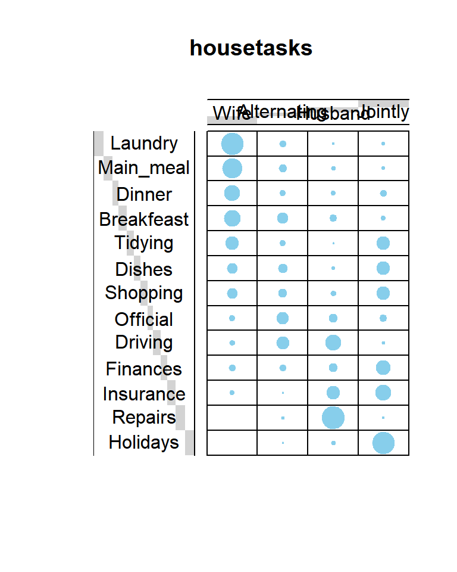

```r
# Correspondence Analysis
if (!require("ca")) install.packages("ca")
library("ca")
library("gplots")
library("factoextra")
data(housetasks)

# 1. convert the data as a table
dt <- as.table(as.matrix(housetasks))
# 2. Graph
balloonplot(t(dt), main = "housetasks", xlab = "", ylab = "",
      label = FALSE, show.margins = FALSE)
```

```r
fit <- ca(dt)
summary(fit) # extended results
```

```
Principal inertias (eigenvalues):

 dim    value      %   cum%   scree plot
 1      0.542889  48.7  48.7  ************
 2      0.445003  39.9  88.6  **********
 3      0.127048  11.4 100.0  ***
        -------- -----
 Total: 1.114940 100.0


Rows:
     name   mass  qlt  inr    k=1 cor ctr    k=2 cor ctr
1  | Lndr |  101  925  120 | -992 740 183 | -495 185  56 |
2  | Mn_m |   88  974   81 | -876 742 124 | -490 232  47 |
3  | Dnnr |   62  930   34 | -693 777  55 | -308 154  13 |
4  | Brkf |   80  905   37 | -509 505  38 | -453 400  37 |
5  | Tdyn |   70  975   22 | -394 440  20 |  434 535  30 |
6  | Dshs |   65  764   18 | -189 118   4 |  442 646  28 |
7  | Shpp |   69  811   13 | -118  64   2 |  403 748  25 |
8  | Offc |   55  119   48 |  227  53   5 | -254  66   8 |
9  | Drvn |   80  767   91 |  742 432  81 | -653 335  76 |
10 | Fnnc |   65  997   27 |  271 161   9 |  618 837  56 |
11 | Insr |   80  885   52 |  647 576  61 |  474 309  40 |
12 | Rprs |   95  933  281 | 1529 707 407 | -864 226 159 |
13 | Hldy |   92  992  176 |  252  30  11 | 1435 962 425 |

Columns:
    name   mass  qlt  inr    k=1 cor ctr    k=2 cor ctr
1 | Wife |  344  954  270 | -838 802 445 | -365 152 103 |
2 | Altr |  146  110  106 |  -62   5   1 | -292 105  28 |
3 | Hsbn |  218  980  342 | 1161 772 542 | -602 208 178 |
4 | Jntl |  292  998  282 |  149  21  12 | 1027 977 691 |
```

[output not shown]

[output cut: 36 more lines]

[output not shown]

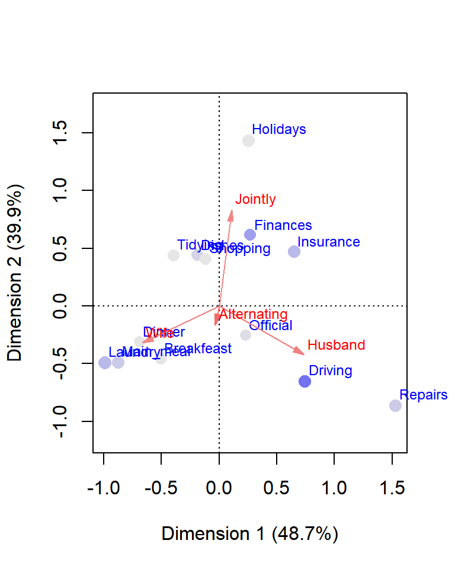

```r
plot(fit, mass = TRUE, contrib = "absolute",
   map = "rowgreen", arrows = c(FALSE, TRUE)) # asymmetric map
```

## Multidimensional Scaling

Multidimensional Scaling (MDS), is a set of multivariate data analysis methods that are used to analyze similarities or dissimilarities in data. One of the nice features of MDS is that it allows us to represent the (dis)similarities among pairs of objects as distances between points in a low-dimensional space. Put another way, MDS allows us to visualize the (dis)similarities in a low-dimensional space for exploration and inspection purposes.

The general approach behind MDS consists of calculating a (dis)similarity matrix among pairs of objects (i.e. observations, individuals, samples, etc), and then apply one of the several MDS “models” to obtain the low-dimensional representation. The MDS model to be applied depends on the type of data, and consequently, the type of (dis)similarity measurement that the analyst decides to use.

Functions can be used for metric MDS analysis are discussed in this [blog](http://www.gastonsanchez.com/visually-enforced/how-to/2013/01/23/MDS-in-R/).

Here we, perform a classical MDS using the cmdscale( ) function.

```r
# Classical MDS
# N rows (objects) x p columns (variables)
# each row identified by a unique row name
euromat <- as.matrix(eurodist)

d <- dist(euromat) # euclidean distances between the rows
fit <- cmdscale(d,eig = TRUE, k = 2) # k is the number of dim
fit # view results
```

```
$points
                      [,1]        [,2]
Athens           6416.1688  5238.29764
Barcelona         824.4657 -2364.87744
Brussels        -2321.7303  -121.65720
Calais          -1939.8986  -361.91339
Cherbourg       -1042.7747  -925.70782
Cologne         -2165.0106   572.75543
Copenhagen       -915.7252  2132.80745
Geneva          -1392.0258  -697.60209
Gibraltar        4880.9172 -3217.83250
Hamburg         -1643.4480  1535.37576
Hook of Holland -2248.4752   379.48422
Lisbon           4148.3195 -3169.05710
Lyons           -1610.1409 -1337.13548
Madrid           2319.2227 -3144.01235
Marseilles       -557.6830 -1320.35030
Milan           -1131.3717    92.87944
Munich          -1635.1036  1048.32590
Paris           -2097.3026  -857.92035
Rome              979.2916  1485.28450
Stockholm        1404.5601  3088.51369
Vienna           -272.2554  1944.34200

$eig
 [1] 1.279805e+08 9.308261e+07 4.260186e+07 6.087057e+06
 [5] 2.724829e+06 1.758749e+06 1.214584e+06 9.402102e+05
 [9] 5.595510e+05 5.326872e+05 3.351144e+05 3.096336e+05
[13] 2.573314e+05 1.527932e+05 9.190940e+04 6.080871e+04
[17] 3.305486e+04 3.021213e+04 1.395004e+04 6.664326e+03
[21] 1.978900e-09

$x
NULL

$ac
[1] 0

$GOF
[1] 0.7929829 0.7929829
```

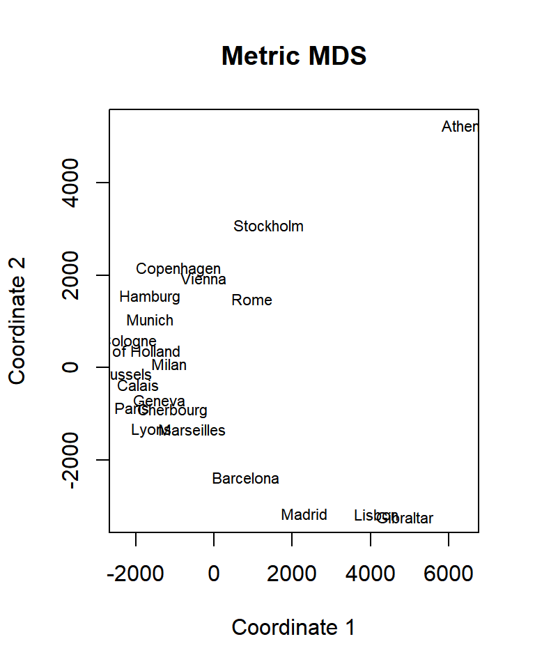

```r
# plot solution
x <- fit$points[,1]
y <- fit$points[,2]
plot(x, y, type = "n", xlab = "Coordinate 1", ylab = "Coordinate 2",
 main = "Metric MDS")
text(x, y, labels = row.names(euromat), cex = .7)
```

Nonmetric MDS is performed using the isoMDS( ) function in the MASS package.

## Cluster Analysis

R has an amazing variety of functions for cluster analysis. In this section, three of the many approaches is touched: hierarchical agglomerative, partitioning, and model based. While there are no best solutions for the problem of determining the number of clusters to extract, several approaches are given below.

1. Data Preparation Prior to clustering data, you may want to remove or estimate missing data and rescale variables for comparability using the tidyr package.
2. Partitioning K-means clustering is the most popular partitioning method. It requires the analyst to specify the number of clusters to extract. A plot of the within groups sum of squares by number of clusters extracted can help determine the appropriate number of clusters. The analyst looks for a bend in the plot similar to a scree test in factor analysis. See Everitt & Hothorn (pg. 251).

```r
library(datasets)
iris <- datasets::iris
iris_new <- iris[,c(1,2,3,4)]
iris_class <- iris[,"Species"]

# Normalization
normalize <- function(x){
 (x - min(x))/(max(x) - min(x))
}

iris_new$Sepal.Length <- normalize(iris_new$Sepal.Length)
iris_new$Sepal.Width <- normalize(iris_new$Sepal.Width)
iris_new$Petal.Length <- normalize(iris_new$Petal.Length)
iris_new$Petal.Width <- normalize(iris_new$Petal.Width)
head(iris_new)
```

|  | Sepal.Length | Sepal.Width | Petal.Length | Petal.Width |
| --- | --- | --- | --- | --- |
| 1 | 0.22222222 | 0.6250000 | 0.06779661 | 0.04166667 |
| 2 | 0.16666667 | 0.4166667 | 0.06779661 | 0.04166667 |
| 3 | 0.11111111 | 0.5000000 | 0.05084746 | 0.04166667 |
| 4 | 0.08333333 | 0.4583333 | 0.08474576 | 0.04166667 |
| 5 | 0.19444444 | 0.6666667 | 0.06779661 | 0.04166667 |
| 6 | 0.30555556 | 0.7916667 | 0.11864407 | 0.12500000 |

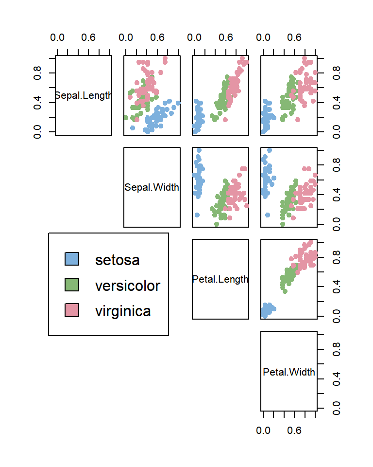

```r
library(colorspace) # get nice colors
species_col <- rev(rainbow_hcl(3))[as.numeric(iris_class)]

# Plot a SPLOM:
pairs(iris_new, col = species_col,
   lower.panel = NULL,
    cex.labels = 1, pch = 19, cex = 1)

# Add a legend
par(xpd = TRUE)
legend(x = 0.05, y = 0.5, cex = 1,
  legend = as.character(levels(iris_class)),
  fill = unique(species_col))
```

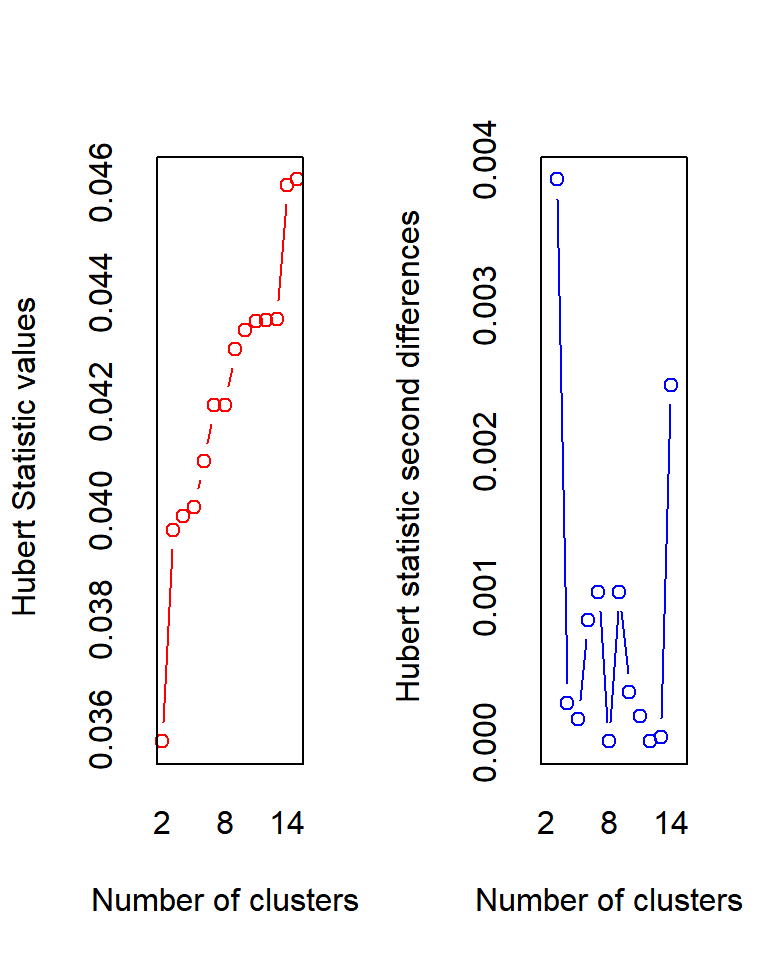

```
*** : The Hubert index is a graphical method of determining the number of clusters.
                In the plot of Hubert index, we seek a significant knee that corresponds to a
                significant increase of the value of the measure i.e the significant peak in Hubert
                index second differences plot.
```

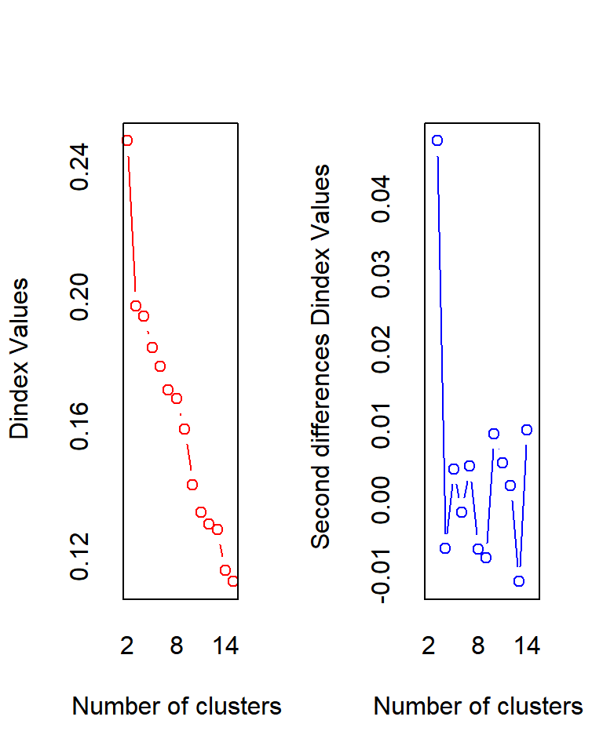

```
*** : The D index is a graphical method of determining the number of clusters.
                In the plot of D index, we seek a significant knee (the significant peak in Dindex
                second differences plot) that corresponds to a significant increase of the value of
                the measure.

* Among all indices:
* 9 proposed 2 as the best number of clusters
* 10 proposed 3 as the best number of clusters
* 1 proposed 4 as the best number of clusters
* 1 proposed 9 as the best number of clusters
* 1 proposed 10 as the best number of clusters
* 2 proposed 15 as the best number of clusters

                   ***** Conclusion *****

* According to the majority rule, the best number of clusters is  3
```

```r
par(xpd = NA)

# Determine number of clusters
if (!require("NbClust")) install.packages("NbClust")
library(NbClust)
devAskNewPage(ask = FALSE)
nc <- NbClust(iris_new, distance = "euclidean",
min.nc = 2, max.nc = 15, method = "average")
```

```r
table(nc$Best.n[1,])
```

```
 0  2  3  4  9 10 15
 2  9 10  1  1  1  2
```

```r
barplot(table(nc$Best.n[1,]), xlab = "Number of Clusters",
    ylab = "Number of Criteria",
    main = "Number of Clusters Chosen by 26 Criteria")

#aplly k-means algorithm with no. of centroids(k) = 3
result<- kmeans(iris_new,3)

# gives no. of records in each cluster
result$size
```

```
[1] 50 39 61
```

```r
# gives value of cluster center datapoint value(3 centers for k = 3)
result$centers
```

```
  Sepal.Length Sepal.Width Petal.Length Petal.Width
1    0.1961111   0.5950000   0.07830508  0.06083333
2    0.7072650   0.4508547   0.79704476  0.82478632
3    0.4412568   0.3073770   0.57571548  0.54918033
```

```r
#gives cluster vector showing the custer where each record falls
result$cluster
```

```
  [1] 1 1 1 1 1 1 1 1 1 1 1 1 1 1 1 1 1 1 1 1 1 1 1 1 1 1 1
 [28] 1 1 1 1 1 1 1 1 1 1 1 1 1 1 1 1 1 1 1 1 1 1 1 2 3 2 3
 [55] 3 3 3 3 3 3 3 3 3 3 3 3 3 3 3 3 3 3 3 3 3 3 3 2 3 3 3
 [82] 3 3 3 3 3 3 3 3 3 3 3 3 3 3 3 3 3 3 3 2 3 2 2 2 2 3 2
[109] 2 2 2 2 2 3 2 2 2 2 2 3 2 3 2 3 2 2 3 3 2 2 2 2 2 3 3
[136] 2 2 2 3 2 2 2 3 2 2 2 3 2 2 3
```

[figure not shown]

```r
# verify clusters
op <- par(mfrow = c(2,2), mar = c(5,4,2,2))
```

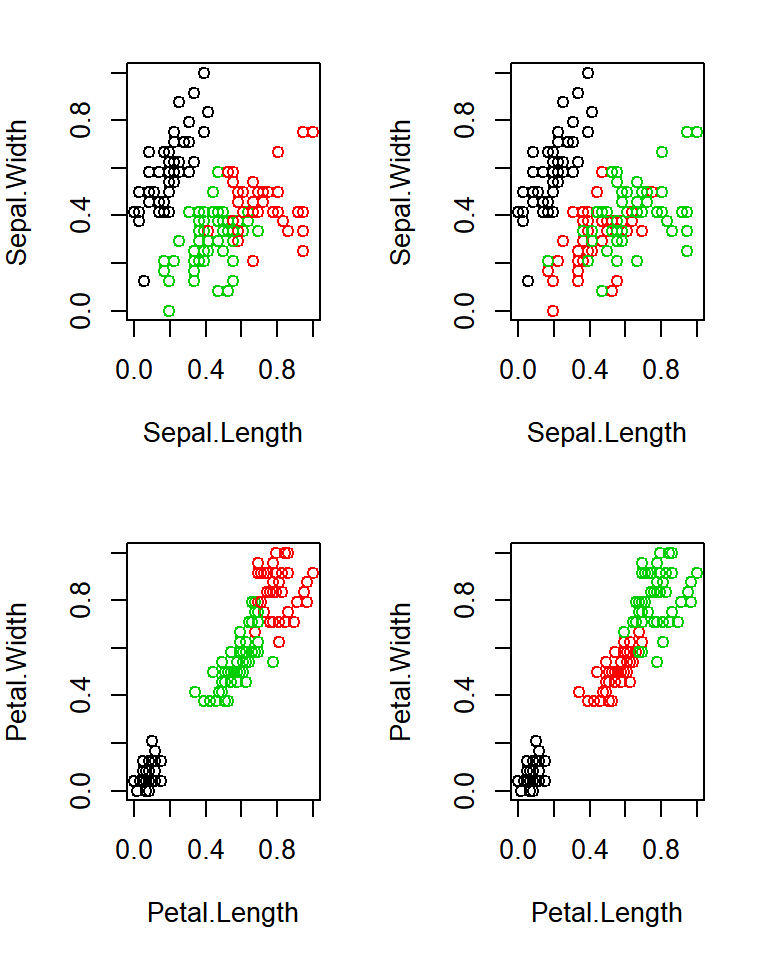

```r
plot(iris_new[c(1,2)], col = result$cluster)# Plot to see how Sepal.Length and Sepal.Width data points have been distributed in clusters
plot(iris_new[c(1,2)], col = iris_class)# Plot to see how Sepal.Length and Sepal.Width data points have been distributed originally as per "class" attribute in dataset
plot(iris_new[c(3,4)], col = result$cluster)# Plot to see how Petal.Length and Petal.Width data points have been distributed in clusters
plot(iris_new[c(3,4)], col = iris_class)
```

```r
par(op)
```

A robust version of K-means based on mediods can be invoked by using pam( ) instead of kmeans( ). The function pamk( ) in the fpc package is a wrapper for pam that also prints the suggested number of clusters based on optimum average silhouette width.

3. Hierarchical Agglomerative There are a wide range of hierarchical clustering approaches.Gene expression data clustering works well with Ward’s method described below.

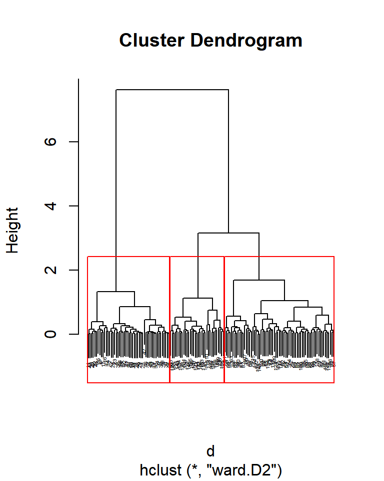

```r
op <- par(mfrow = c(1,1))
# Ward Hierarchical Clustering
d <- dist(iris_new, method = "euclidean") # distance matrix
fit <- hclust(d, method = "ward.D2")
plot(fit, cex = 0.3) # display dendogram
groups <- cutree(fit, k = 3) # cut tree into 5 clusters
# draw dendogram with red borders around the 5 clusters
rect.hclust(fit, k = 3, border = "red")
```

```r
par(op)
```

The pvclust( ) function in the pvclust package provides p-values for hierarchical clustering based on multiscale bootstrap resampling. Clusters that are highly supported by the data will have large p values. Interpretation details are provided Suzuki. Be aware that pvclust clusters columns, not rows. Transpose your data before using.

```r
# Ward Hierarchical Clustering with Bootstrapped p values
if (!require("pvclust")) install.packages("pvclust")
library(pvclust)
fit <- pvclust(iris_new, method.hclust = "ward.D2",
  method.dist = "euclidean")
```

```
Bootstrap (r = 0.5)... Done.
Bootstrap (r = 0.6)... Done.
Bootstrap (r = 0.7)... Done.
Bootstrap (r = 0.8)... Done.
Bootstrap (r = 0.9)... Done.
Bootstrap (r = 1.0)... Done.
Bootstrap (r = 1.1)... Done.
Bootstrap (r = 1.2)... Done.
Bootstrap (r = 1.3)... Done.
Bootstrap (r = 1.4)... Done.
```

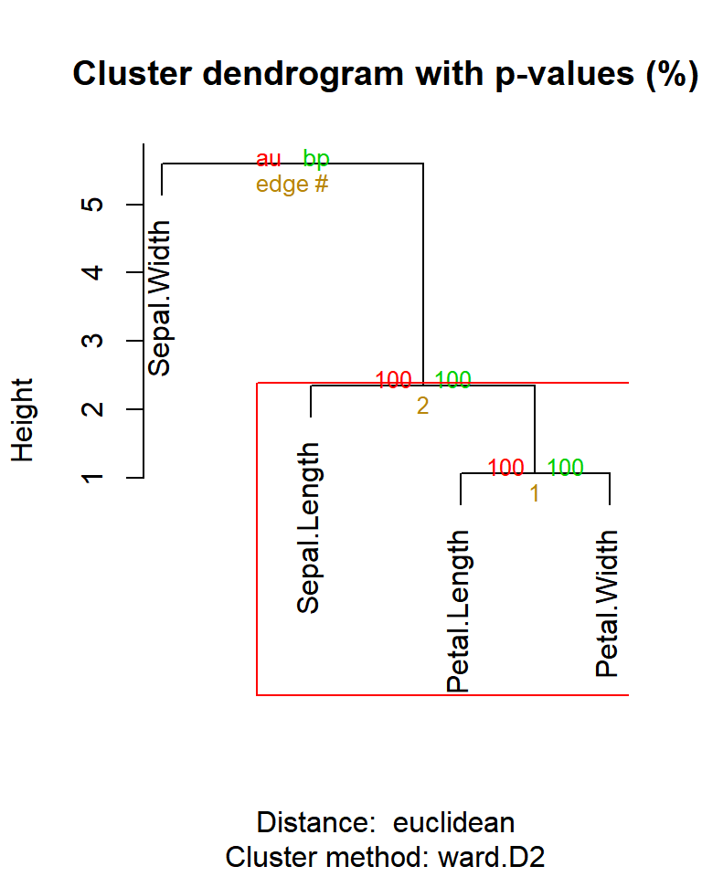

```r
plot(fit) # dendogram with p values
# add rectangles around groups highly supported by the data
pvrect(fit, alpha = .95)
```

4. Model Based Clustering Model based approaches assume a variety of data models and apply maximum likelihood estimation and Bayes criteria to identify the most likely model and number of clusters. Specifically, the Mclust( ) function in the mclust package selects the optimal model according to BIC for EM initialized by hierarchical clustering for parameterized Gaussian mixture models. (phew!). One chooses the model and number of clusters with the largest BIC. See help(mclustModelNames) to details on the model chosen as best.

```r
# Model Based Clustering
library(mclust)
fit <- Mclust(iris_new)
plot(fit) # plot results
summary(fit) # display the best model
```

[output not shown]

5. Plotting Cluster Solutions It is always a good idea to look at the cluster results.

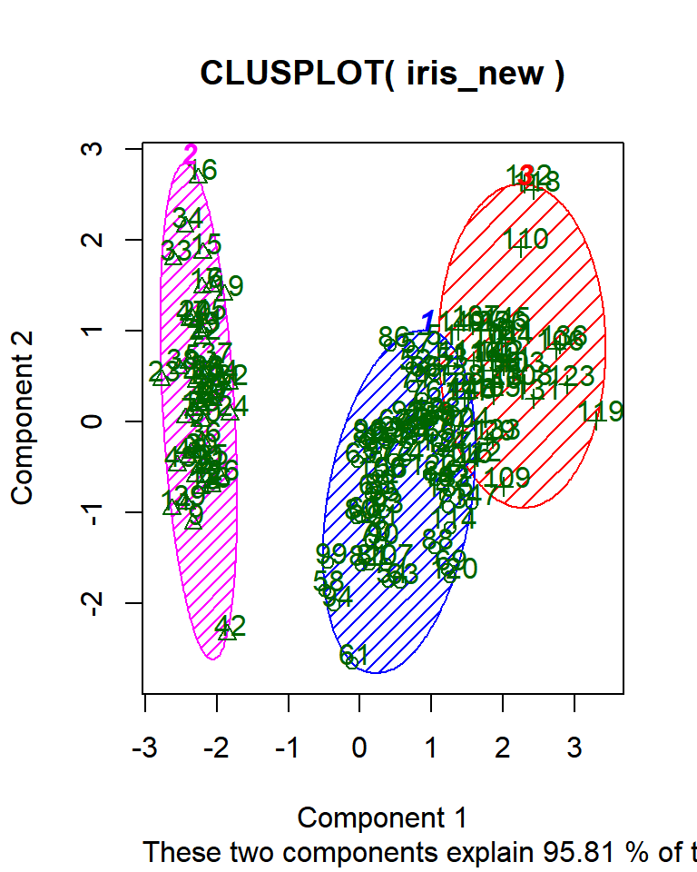

```r
# K-Means Clustering with 3 clusters
fit <- kmeans(iris_new, 3)

# Cluster Plot against 1st 2 principal components

# vary parameters for most readable graph
library(cluster)
clusplot(iris_new, fit$cluster, color = TRUE, shade = TRUE,
  labels = 2, lines = 0)
```

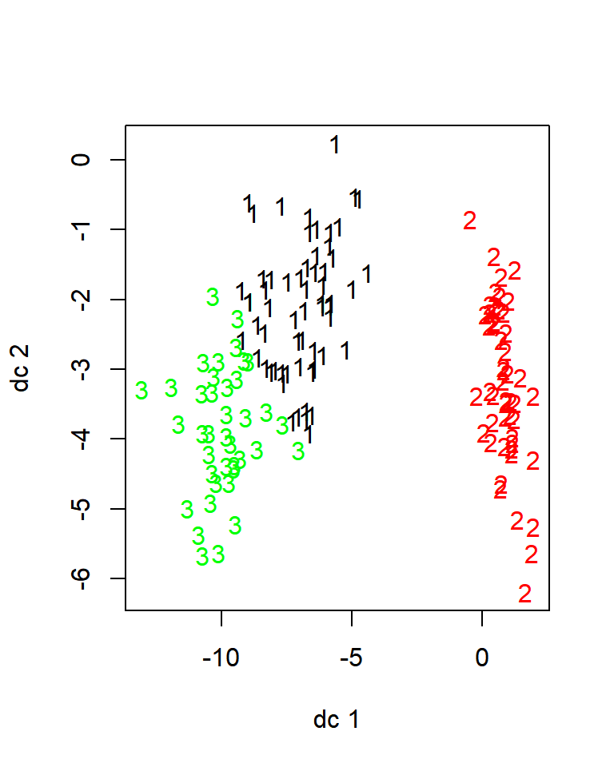

```r
# Centroid Plot against 1st 2 discriminant functions
if (!require("fpc")) install.packages("fpc")
library(fpc)
plotcluster(iris_new, fit$cluster)
```

6. Validating cluster solutions The function cluster.stats() in the fpc package provides a mechanism for comparing the similarity of two cluster solutions using a variety of validation criteria (Hubert’s gamma coefficient, the Dunn index and the corrected rand index)

```r
# comparing 2 cluster solutions

library(fpc)
cluster.stats(d, fit1$cluster, fit2$cluster)
```

where d is a distance matrix among objects, and **fit1$cluster and fit$cluster** are integer vectors containing classification results from two different clustering of the same data.

One way to assess whether a cluster represents true structure is to see if the cluster holds up under plausible variations in the dataset. The fpc package has a function called clusterboot()that uses bootstrap resampling to evaluate how stable a given cluster is. See this [page](http://www.win-vector.com/blog/2015/09/bootstrap-evaluation-of-clusters/)

to demo, we use this [dataset](https://github.com/WinVector/zmPDSwR/blob/master/Protein/protein.txt).

```r
protein <- read.table("data/protein.txt", sep = "\t", header = TRUE)
summary(protein)
```

```
           Country      RedMeat         WhiteMeat
 Albania       : 1   Min.   : 4.400   Min.   : 1.400
 Austria       : 1   1st Qu.: 7.800   1st Qu.: 4.900
 Belgium       : 1   Median : 9.500   Median : 7.800
 Bulgaria      : 1   Mean   : 9.828   Mean   : 7.896
 Czechoslovakia: 1   3rd Qu.:10.600   3rd Qu.:10.800
 Denmark       : 1   Max.   :18.000   Max.   :14.000
 (Other)       :19
      Eggs            Milk            Fish
 Min.   :0.500   Min.   : 4.90   Min.   : 0.200
 1st Qu.:2.700   1st Qu.:11.10   1st Qu.: 2.100
 Median :2.900   Median :17.60   Median : 3.400
 Mean   :2.936   Mean   :17.11   Mean   : 4.284
 3rd Qu.:3.700   3rd Qu.:23.30   3rd Qu.: 5.800
 Max.   :4.700   Max.   :33.70   Max.   :14.200

    Cereals          Starch           Nuts
 Min.   :18.60   Min.   :0.600   Min.   :0.700
 1st Qu.:24.30   1st Qu.:3.100   1st Qu.:1.500
 Median :28.00   Median :4.700   Median :2.400
 Mean   :32.25   Mean   :4.276   Mean   :3.072
 3rd Qu.:40.10   3rd Qu.:5.700   3rd Qu.:4.700
 Max.   :56.70   Max.   :6.500   Max.   :7.800

     Fr.Veg
 Min.   :1.400
 1st Qu.:2.900
 Median :3.800
 Mean   :4.136
 3rd Qu.:4.900
 Max.   :7.900
```

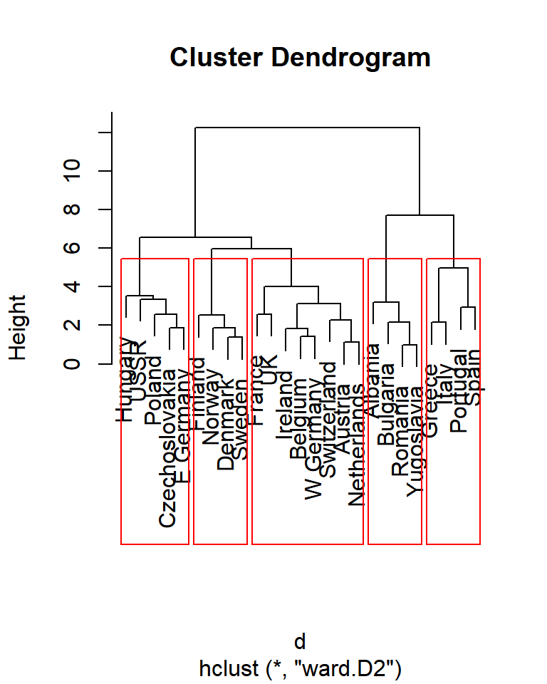

```r
vars.to.use <- colnames(protein)[-1]

# Scale the data columns to be zero mean
# and unit variance.
# The output of scale() is a matricx.
pmatrix <- scale(protein[,vars.to.use])

# optionally, store the centers and
# standard deviations of the original data,
# so you can "unscale" it later.
pcenter <- attr(pmatrix, "scaled:center")
pscale <- attr(pmatrix, "scaled:scale")

#  Create the distance matrix.
d <- dist(pmatrix, method = "euclidean")

#  Do the clustering.
pfit <- hclust(d, method = "ward.D2")

#  Plot the dendrogram.
plot(pfit, labels = protein$Country)

rect.hclust(pfit, k = 5)
```

```r
# A convenience function for printing out the countries in each cluster, along with the values for red meat, fish, and fruit/vegetable consumption.
print_clusters <- function(labels, k) {
 for(i in 1:k) {
  print(paste("cluster", i))
  print(protein[labels == i,c("Country","RedMeat","Fish","Fr.Veg")])
 }
}

# get the cluster labels
groups <- cutree(pfit, k = 5)

# load the fpc package
library(fpc)

# set the desired number of clusters
kbest.p <- 5

#  Run clusterboot() with hclust
#  ('clustermethod = hclustCBI') using Ward's method
#  ('method = "ward"') and kbest.p clusters
#  ('k = kbest.p'). Return the results in an object
#  called cboot.hclust.
cboot.hclust <- clusterboot(pmatrix,
                            clustermethod = hclustCBI,
                            count = FALSE,
                            method = "ward.D2", k = kbest.p)

#  The results of the clustering are in
#  cboot.hclust$result. The output of the hclust()
#  function is in cboot.hclust$result$result.
#
#  cboot.hclust$result$partition returns a
#  vector of clusterlabels.
groups <- cboot.hclust$result$partition

# The vector of cluster stabilities.
# Values close to 1 indicate stable clusters
cboot.hclust$bootmean
```

```
[1] 0.8078333 0.7994365 0.6530952 0.8745317 0.7630000
```

```r
# The count of how many times each cluster was
# dissolved. By default clusterboot() runs 100
# bootstrap iterations.
# Clusters that are dissolved often are unstable.
cboot.hclust$bootbrd
```

```
[1] 20 12 49 16 31
```

## Classification

A hot topic in machine/statistical learning. We will not go into it here. If you are interested, please familiarize yourself by reading this [page](https://data-flair.training/blogs/classification-in-r/).